# PEC1

Laura Sudupe

13/10/2020

EJERCICIO 1. Resuelve las siguientes cuestiones, mostrando las instrucciones de código utilizadas así como el resultado de la ejecución de dicho código. 1.1. Importa los datos del fichero Health_heart.csv correspondientes a la probabilidad de sufrir un ataque al corazón. Guarda estos datos en un data frame llamado health_heart y muestra los primeros y últimos registros del conjunto de datos.

```r
health_heart <- read.csv("/Users/lsudu/code/rlab/PEC1/heart.csv")
head(health_heart)
```

|  | ï..age | sex | cp | trestbps | chol | fbs | restecg | thalach | exang | oldpeak | slope | ca | thal | target |
| --- | --- | --- | --- | --- | --- | --- | --- | --- | --- | --- | --- | --- | --- | --- |
| 1 | 63 | 1 | 3 | 145 | 233 | 1 | 0 | 150 | 0 | 2.3 | 0 | 0 | 1 | 1 |
| 2 | 37 | 1 | 2 | 130 | 250 | 0 | 1 | 187 | 0 | 3.5 | 0 | 0 | 2 | 1 |
| 3 | 41 | 0 | 1 | 130 | 204 | 0 | 0 | 172 | 0 | 1.4 | 2 | 0 | 2 | 1 |
| 4 | 56 | 1 | 1 | 120 | 236 | 0 | 1 | 178 | 0 | 0.8 | 2 | 0 | 2 | 1 |
| 5 | 57 | 0 | 0 | 120 | 354 | 0 | 1 | 163 | 1 | 0.6 | 2 | 0 | 2 | 1 |
| 6 | 57 | 1 | 0 | 140 | 192 | 0 | 1 | 148 | 0 | 0.4 | 1 | 0 | 1 | 1 |

```r
tail(health_heart)
```

|  | ï..age | sex | cp | trestbps | chol | fbs | restecg | thalach | exang | oldpeak | slope | ca | thal | target |
| --- | --- | --- | --- | --- | --- | --- | --- | --- | --- | --- | --- | --- | --- | --- |
| 298 | 59 | 1 | 0 | 164 | 176 | 1 | 0 | 90 | 0 | 1.0 | 1 | 2 | 1 | 0 |
| 299 | 57 | 0 | 0 | 140 | 241 | 0 | 1 | 123 | 1 | 0.2 | 1 | 0 | 3 | 0 |
| 300 | 45 | 1 | 3 | 110 | 264 | 0 | 1 | 132 | 0 | 1.2 | 1 | 0 | 3 | 0 |
| 301 | 68 | 1 | 0 | 144 | 193 | 1 | 1 | 141 | 0 | 3.4 | 1 | 2 | 3 | 0 |
| 302 | 57 | 1 | 0 | 130 | 131 | 0 | 1 | 115 | 1 | 1.2 | 1 | 1 | 3 | 0 |
| 303 | 57 | 0 | 1 | 130 | 236 | 0 | 0 | 174 | 0 | 0.0 | 1 | 1 | 2 | 0 |

1.2. A partir del data frame definido, health_heart, muestra algunas características como: a) Nombre de las variables que forman el conjunto de datos.

```r
names(health_heart)
```

```
##  [1] "ï..age"   "sex"      "cp"       "trestbps" "chol"     "fbs"
##  [7] "restecg"  "thalach"  "exang"    "oldpeak"  "slope"    "ca"
## [13] "thal"     "target"
```

2. Estructura del conjunto de datos

```r
str(health_heart)
```

```
## 'data.frame':    303 obs. of  14 variables:
##  $ ï..age  : int  63 37 41 56 57 57 56 44 52 57 ...
##  $ sex     : int  1 1 0 1 0 1 0 1 1 1 ...
##  $ cp      : int  3 2 1 1 0 0 1 1 2 2 ...
##  $ trestbps: int  145 130 130 120 120 140 140 120 172 150 ...
##  $ chol    : int  233 250 204 236 354 192 294 263 199 168 ...
##  $ fbs     : int  1 0 0 0 0 0 0 0 1 0 ...
##  $ restecg : int  0 1 0 1 1 1 0 1 1 1 ...
##  $ thalach : int  150 187 172 178 163 148 153 173 162 174 ...
##  $ exang   : int  0 0 0 0 1 0 0 0 0 0 ...
##  $ oldpeak : num  2.3 3.5 1.4 0.8 0.6 0.4 1.3 0 0.5 1.6 ...
##  $ slope   : int  0 0 2 2 2 1 1 2 2 2 ...
##  $ ca      : int  0 0 0 0 0 0 0 0 0 0 ...
##  $ thal    : int  1 2 2 2 2 1 2 3 3 2 ...
##  $ target  : int  1 1 1 1 1 1 1 1 1 1 ...
```

3. Tamaño de la muestra y número de variables

```r
dim(health_heart)
```

```
## [1] 303  14
```

4. ¿Existen valores nulos en el conjunto de datos?

```r
table(is.null(health_heart))
```

```
##
## FALSE
##     1
```

5. ¿Existen datos perdidos (missing values) en la tabla?

```r
table(is.na(health_heart))
```

```
##
## FALSE
##  4242
```

EJERCICIO 2. Definid un data frame, dataHealthHeart_w, y otro data frame, dataHealthHeart_m, que corresponderán a los conjuntos de datos de las mujeres y de los hombres, respectivamente. Posteriormente, exportad ambos data frame a dos ficheros (HealthHeart_w,HealthHeart_m) de tipo csv.

```r
#health_heart <- read.csv("/Users/lsudu/code/rlab/LAB2/PEC1/heart.csv")
health_heart$sex <- factor(health_heart$sex, levels=c("0","1"),
                       labels=c("male","female"))
#Hice el ejercicio pensando que 0 se le asignaba al hombre y 1 a la mujer

dataHealthHeart_w <- data.frame(subset(health_heart,
                                       health_heart$sex == "female"))
dataHealthHeart_m <- data.frame(subset(health_heart,
                                health_heart$sex == "male"))

write.csv(dataHealthHeart_w, file=
            "/Users/lsudu/code/rlab/PEC1/HealthHeart_w.csv")

write.csv(dataHealthHeart_m, file =
            "/Users/lsudu/code/rlab/PEC1/HealthHeart_m.csv")
```

EJERCICIO 3. Considerando el data frame health_heart, resolver las siguientes cuestiones: a) ¿Cuál es la media de edad, que definiremos como age_mean, de los pacientes de la muestra de datos?

```r
#health_heart <- read.csv("/Users/lsudu/code/rlab/LAB2/PEC1/heart.csv")

#primero voy a renombrar la columna 'ï..age'
#install.packages("tidyverse")
library(plyr)
health_heart <- rename(health_heart, c("ï..age" = "age" ))

age_mean <- mean(health_heart$age)
```

2. Definid una variable, age_max_trestbps, que guarde la edad del paciente que registra el máximo valor de presión arterial.

```r
age_max_trestbps <- health_heart$age[max(health_heart$trestbps)]
```

3. Mostrad los/as pacientes cuya probabilidad de tener un ataque al corazón (target=0(menor probabilidad), target=1 (mayor probabilidad)) considerando aquellos/as pacientes con presión arterial (trestbps) superior a la media.

```r
high_heart_attack_prob <- health_heart$target[health_heart$trestbps >
                                                  mean(health_heart$trestbps)]
high_heart_attack_prob
```

```
##   [1] 1 1 1 1 1 1 1 1 1 1 1 1 1 1 1 1 1 1 1 1 1 1 1 1 1 1 1 1 1 1 1 1 1 1 1 1 1
##  [38] 1 1 1 1 1 1 1 1 1 1 1 1 1 1 1 1 1 1 1 1 1 1 1 1 1 1 1 1 0 0 0 0 0 0 0 0 0
##  [75] 0 0 0 0 0 0 0 0 0 0 0 0 0 0 0 0 0 0 0 0 0 0 0 0 0 0 0 0 0 0 0 0 0 0 0 0 0
## [112] 0 0 0 0 0 0 0 0 0 0 0 0 0 0 0 0 0 0 0 0 0
```

4. Definid un data frame, heartAttack_chance_0, que contenga los/as pacientes cuya probabilidad de sufrir un ataque al corazón sea baja (target=0). A partir de este data frame, definid un vector que contenga los valores máximos de las variables edad “age”, colesterol “chol” y pulsaciones “thalach”.

```r
heartAttack_chance_0 <- subset(health_heart, health_heart$target == "0")
heartAttack_chance_0
```

|  | age | sex | cp | trestbps | chol | fbs | restecg | thalach | exang | oldpeak | slope | ca | thal | target |
| --- | --- | --- | --- | --- | --- | --- | --- | --- | --- | --- | --- | --- | --- | --- |
| 166 | 67 | female | 0 | 160 | 286 | 0 | 0 | 108 | 1 | 1.5 | 1 | 3 | 2 | 0 |
| 167 | 67 | female | 0 | 120 | 229 | 0 | 0 | 129 | 1 | 2.6 | 1 | 2 | 3 | 0 |
| 168 | 62 | male | 0 | 140 | 268 | 0 | 0 | 160 | 0 | 3.6 | 0 | 2 | 2 | 0 |
| 169 | 63 | female | 0 | 130 | 254 | 0 | 0 | 147 | 0 | 1.4 | 1 | 1 | 3 | 0 |
| 170 | 53 | female | 0 | 140 | 203 | 1 | 0 | 155 | 1 | 3.1 | 0 | 0 | 3 | 0 |
| 171 | 56 | female | 2 | 130 | 256 | 1 | 0 | 142 | 1 | 0.6 | 1 | 1 | 1 | 0 |
| 172 | 48 | female | 1 | 110 | 229 | 0 | 1 | 168 | 0 | 1.0 | 0 | 0 | 3 | 0 |
| 173 | 58 | female | 1 | 120 | 284 | 0 | 0 | 160 | 0 | 1.8 | 1 | 0 | 2 | 0 |
| 174 | 58 | female | 2 | 132 | 224 | 0 | 0 | 173 | 0 | 3.2 | 2 | 2 | 3 | 0 |
| 175 | 60 | female | 0 | 130 | 206 | 0 | 0 | 132 | 1 | 2.4 | 1 | 2 | 3 | 0 |

[output cut: 128 more lines]

```r
vector <- c(max(heartAttack_chance_0$age), max(heartAttack_chance_0$chol),
            max(heartAttack_chance_0$thalach))
vector
```

```
## [1]  77 409 195
```

5. Definid una matriz que muestre las columnas “age” y “sex”.

```r
matrix_health <- matrix(c(health_heart$age, health_heart$sex), ncol=2)
head(matrix_health)
```

```
##      [,1] [,2]
## [1,]   63    2
## [2,]   37    2
## [3,]   41    1
## [4,]   56    2
## [5,]   57    1
## [6,]   57    2
```

```r
matrix_hearAttack <- matrix(c(heartAttack_chance_0$age,
                              heartAttack_chance_0$sex), ncol=2)
head(matrix_hearAttack)
```

```
##      [,1] [,2]
## [1,]   67    2
## [2,]   67    2
## [3,]   62    1
## [4,]   63    2
## [5,]   53    2
## [6,]   56    2
```

EJERCICIO 4. a) Realizad un resumen estadístico de health_heart que muestre los parámetros básicos más importantes.

```r
health_heart_num <- read.csv("/Users/lsudu/code/rlab/PEC1/heart.csv")
head(health_heart) #observamos que columnas tenemos
```

|  | age | sex | cp | trestbps | chol | fbs | restecg | thalach | exang | oldpeak | slope | ca | thal | target |
| --- | --- | --- | --- | --- | --- | --- | --- | --- | --- | --- | --- | --- | --- | --- |
| 1 | 63 | female | 3 | 145 | 233 | 1 | 0 | 150 | 0 | 2.3 | 0 | 0 | 1 | 1 |
| 2 | 37 | female | 2 | 130 | 250 | 0 | 1 | 187 | 0 | 3.5 | 0 | 0 | 2 | 1 |
| 3 | 41 | male | 1 | 130 | 204 | 0 | 0 | 172 | 0 | 1.4 | 2 | 0 | 2 | 1 |
| 4 | 56 | female | 1 | 120 | 236 | 0 | 1 | 178 | 0 | 0.8 | 2 | 0 | 2 | 1 |
| 5 | 57 | male | 0 | 120 | 354 | 0 | 1 | 163 | 1 | 0.6 | 2 | 0 | 2 | 1 |
| 6 | 57 | female | 0 | 140 | 192 | 0 | 1 | 148 | 0 | 0.4 | 1 | 0 | 1 | 1 |

```r
summary(health_heart) #nos da un vistazo de la descripcion estadistica
```

```
##       age            sex            cp           trestbps          chol
##  Min.   :29.00   male  : 96   Min.   :0.000   Min.   : 94.0   Min.   :126.0
##  1st Qu.:47.50   female:207   1st Qu.:0.000   1st Qu.:120.0   1st Qu.:211.0
##  Median :55.00                Median :1.000   Median :130.0   Median :240.0
##  Mean   :54.37                Mean   :0.967   Mean   :131.6   Mean   :246.3
##  3rd Qu.:61.00                3rd Qu.:2.000   3rd Qu.:140.0   3rd Qu.:274.5
##  Max.   :77.00                Max.   :3.000   Max.   :200.0   Max.   :564.0
##       fbs            restecg          thalach          exang
##  Min.   :0.0000   Min.   :0.0000   Min.   : 71.0   Min.   :0.0000
##  1st Qu.:0.0000   1st Qu.:0.0000   1st Qu.:133.5   1st Qu.:0.0000
##  Median :0.0000   Median :1.0000   Median :153.0   Median :0.0000
##  Mean   :0.1485   Mean   :0.5281   Mean   :149.6   Mean   :0.3267
##  3rd Qu.:0.0000   3rd Qu.:1.0000   3rd Qu.:166.0   3rd Qu.:1.0000
##  Max.   :1.0000   Max.   :2.0000   Max.   :202.0   Max.   :1.0000
##     oldpeak         slope             ca              thal
##  Min.   :0.00   Min.   :0.000   Min.   :0.0000   Min.   :0.000
##  1st Qu.:0.00   1st Qu.:1.000   1st Qu.:0.0000   1st Qu.:2.000
##  Median :0.80   Median :1.000   Median :0.0000   Median :2.000
##  Mean   :1.04   Mean   :1.399   Mean   :0.7294   Mean   :2.314
##  3rd Qu.:1.60   3rd Qu.:2.000   3rd Qu.:1.0000   3rd Qu.:3.000
##  Max.   :6.20   Max.   :2.000   Max.   :4.0000   Max.   :3.000
##      target
##  Min.   :0.0000
##  1st Qu.:0.0000
##  Median :1.0000
##  Mean   :0.5446
##  3rd Qu.:1.0000
##  Max.   :1.0000
```

```r
cor(health_heart_num) #vemos que dependencia tienen las variables entre si. Baja
```

```
##               ï..age         sex          cp    trestbps         chol
## ï..age    1.00000000 -0.09844660 -0.06865302  0.27935091  0.213677957
## sex      -0.09844660  1.00000000 -0.04935288 -0.05676882 -0.197912174
## cp       -0.06865302 -0.04935288  1.00000000  0.04760776 -0.076904391
## trestbps  0.27935091 -0.05676882  0.04760776  1.00000000  0.123174207
## chol      0.21367796 -0.19791217 -0.07690439  0.12317421  1.000000000
## fbs       0.12130765  0.04503179  0.09444403  0.17753054  0.013293602
## restecg  -0.11621090 -0.05819627  0.04442059 -0.11410279 -0.151040078
## thalach  -0.39852194 -0.04401991  0.29576212 -0.04669773 -0.009939839
## exang     0.09680083  0.14166381 -0.39428027  0.06761612  0.067022783
## oldpeak   0.21001257  0.09609288 -0.14923016  0.19321647  0.053951920
## slope    -0.16881424 -0.03071057  0.11971659 -0.12147458 -0.004037770
## ca        0.27632624  0.11826141 -0.18105303  0.10138899  0.070510925
## thal      0.06800138  0.21004110 -0.16173557  0.06220989  0.098802993
## target   -0.22543872 -0.28093658  0.43379826 -0.14493113 -0.085239105
##                   fbs     restecg      thalach       exang      oldpeak
## ï..age    0.121307648 -0.11621090 -0.398521938  0.09680083  0.210012567
## sex       0.045031789 -0.05819627 -0.044019908  0.14166381  0.096092877
## cp        0.094444035  0.04442059  0.295762125 -0.39428027 -0.149230158
## trestbps  0.177530542 -0.11410279 -0.046697728  0.06761612  0.193216472
## chol      0.013293602 -0.15104008 -0.009939839  0.06702278  0.053951920
## fbs       1.000000000 -0.08418905 -0.008567107  0.02566515  0.005747223
## restecg  -0.084189054  1.00000000  0.044123444 -0.07073286 -0.058770226
## thalach  -0.008567107  0.04412344  1.000000000 -0.37881209 -0.344186948
## exang     0.025665147 -0.07073286 -0.378812094  1.00000000  0.288222808
## oldpeak   0.005747223 -0.05877023 -0.344186948  0.28822281  1.000000000
## slope    -0.059894178  0.09304482  0.386784410 -0.25774837 -0.577536817
## ca        0.137979327 -0.07204243 -0.213176928  0.11573938  0.222682322
## thal     -0.032019339 -0.01198140 -0.096439132  0.20675379  0.210244126
## target   -0.028045760  0.13722950  0.421740934 -0.43675708 -0.430696002
##                slope          ca        thal      target
## ï..age   -0.16881424  0.27632624  0.06800138 -0.22543872
## sex      -0.03071057  0.11826141  0.21004110 -0.28093658
## cp        0.11971659 -0.18105303 -0.16173557  0.43379826
## trestbps -0.12147458  0.10138899  0.06220989 -0.14493113
## chol     -0.00403777  0.07051093  0.09880299 -0.08523911
## fbs      -0.05989418  0.13797933 -0.03201934 -0.02804576
## restecg   0.09304482 -0.07204243 -0.01198140  0.13722950
## thalach   0.38678441 -0.21317693 -0.09643913  0.42174093
## exang    -0.25774837  0.11573938  0.20675379 -0.43675708
## oldpeak  -0.57753682  0.22268232  0.21024413 -0.43069600
## slope     1.00000000 -0.08015521 -0.10476379  0.34587708
## ca       -0.08015521  1.00000000  0.15183213 -0.39172399
## thal     -0.10476379  0.15183213  1.00000000 -0.34402927
## target    0.34587708 -0.39172399 -0.34402927  1.00000000
```

```r
sapply(health_heart_num, mean) #echamos un vistazo a la media de todas las variables.
```

```
##      ï..age         sex          cp    trestbps        chol         fbs
##  54.3663366   0.6831683   0.9669967 131.6237624 246.2640264   0.1485149
##     restecg     thalach       exang     oldpeak       slope          ca
##   0.5280528 149.6468647   0.3267327   1.0396040   1.3993399   0.7293729
##        thal      target
##   2.3135314   0.5445545
```

2. Definid un vector con la probabilidad de sufrir un ataque (target).

Etiquetad la variable “target” con “Menor” si el valor es 0 y “Mayor” si el valor es 1.

```r
health_heart$target <- factor(health_heart$target, levels=c(0,1),
                              labels=c("Menor", "Mayor"))
prob_attack <- c(health_heart$target)
```

3. Definid un vector con los niveles de colesterol (chol) de los/as pacientes, después ordenad dicho vector, calculad la media, la varianza y desviación estándar.

```r
chol_patient <- c(health_heart$chol)
chol_patient <- sort(chol_patient)
chol_patient_mean <- mean(chol_patient)
chol_patient_var <- var(chol_patient)
chol_patient_sd <- sd(chol_patient)
```

4. Mostrad las tablas de frecuencias relativas y absolutas de los vectores de la edad (age) y la probabilidad (target). Posteriormente representad una tabla de frecuencias relativas cruzadas, de manera que podamos visualizar cuántos/as pacientes según edad, tiene una probabilidad mayor o menor.

```r
age_patient <- c(health_heart$age)
target_patient <- c(health_heart$target)

prop.table(table(age_patient, target_patient))
```

```
##            target_patient
## age_patient          1          2
##          29 0.00000000 0.00330033
##          34 0.00000000 0.00660066
##          35 0.00660066 0.00660066
##          37 0.00000000 0.00660066
##          38 0.00330033 0.00660066
##          39 0.00330033 0.00990099
##          40 0.00660066 0.00330033
##          41 0.00330033 0.02970297
##          42 0.00330033 0.02310231
##          43 0.00990099 0.01650165
##          44 0.00990099 0.02640264
##          45 0.00660066 0.01980198
##          46 0.00990099 0.01320132
```

[output cut: 28 more lines]

EJERCICIO 5. Realizad los siguientes gráficos: a) Diagrama de tallo y hojas de la variable “age”.

```r
stem(health_heart$age, scale=1, width=80)
```

```
##
##   The decimal point is at the |
##
##   28 | 0
##   30 |
##   32 |
##   34 | 000000
##   36 | 00
##   38 | 0000000
##   40 | 0000000000000
##   42 | 0000000000000000
##   44 | 0000000000000000000
##   46 | 000000000000
##   48 | 000000000000
##   50 | 0000000000000000000
##   52 | 000000000000000000000
##   54 | 000000000000000000000000
##   56 | 0000000000000000000000000000
##   58 | 000000000000000000000000000000000
##   60 | 0000000000000000000
##   62 | 00000000000000000000
##   64 | 000000000000000000
##   66 | 0000000000000000
##   68 | 0000000
##   70 | 0000000
##   72 |
##   74 | 0
##   76 | 00
```

2. Diagrama de cajas y bigotes de la variable “chol”.

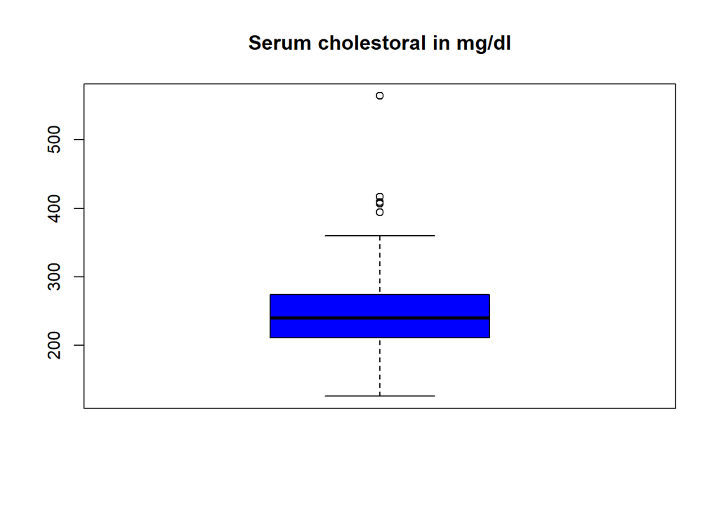

```r
boxplot(health_heart$chol,main = "Serum cholestoral in mg/dl",  col="blue")
```

4. Diagrama de puntos de la variable “thalach” (frecuencia cardíaca máxima alcanzada).

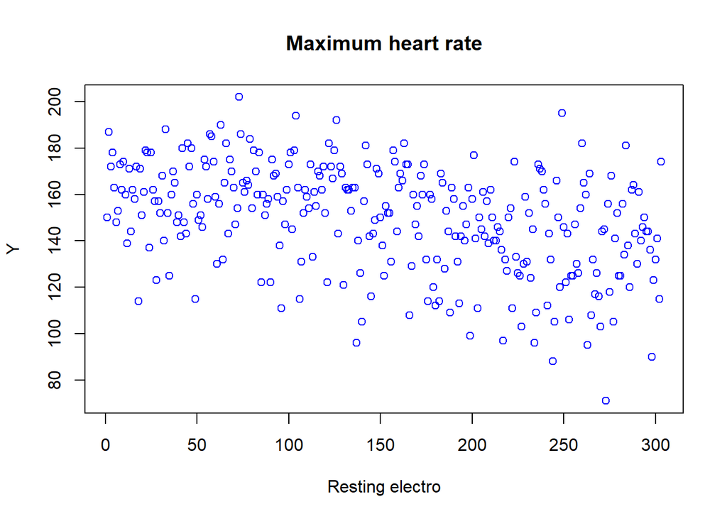

```r
plot(health_heart$thalach, main= "Maximum heart rate",
     col="blue", xlab="Resting electro", ylab ="Y")
```

5. Combinad los gráficos anteriores en una representación gráfica común. Podéis utilizar la función layout() para ajustar la distribución de los gráficos si fuera necesario.

```r
par(mfrow=c(1,3))
boxplot(health_heart$chol,main = "Serum cholestoral in mg/dl", col="blue")
stem(health_heart$age, scale=1, width=80)
```

```
##
##   The decimal point is at the |
##
##   28 | 0
##   30 |
##   32 |
##   34 | 000000
##   36 | 00
##   38 | 0000000
##   40 | 0000000000000
##   42 | 0000000000000000
##   44 | 0000000000000000000
##   46 | 000000000000
##   48 | 000000000000
##   50 | 0000000000000000000
##   52 | 000000000000000000000
##   54 | 000000000000000000000000
##   56 | 0000000000000000000000000000
##   58 | 000000000000000000000000000000000
##   60 | 0000000000000000000
##   62 | 00000000000000000000
##   64 | 000000000000000000
##   66 | 0000000000000000
##   68 | 0000000
##   70 | 0000000
##   72 |
##   74 | 0
##   76 | 00
```

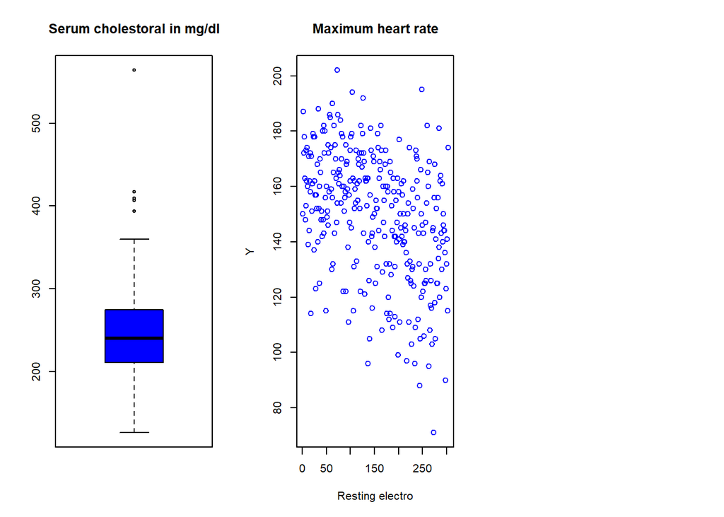

```r
plot(health_heart$thalach,main= "Maximum heart rate",
     col="blue", xlab="Resting electro", ylab ="Y")
```

EJERCICIO 6. A partir del data frame “health_heart” se pide resolver las siguientes cuestiones. 6.1. Utilizando el paquete de gráficos ggplot2, se pide: a) Realizar un gráfico de tipo qplot de la variable “age” y la variable “chol”.

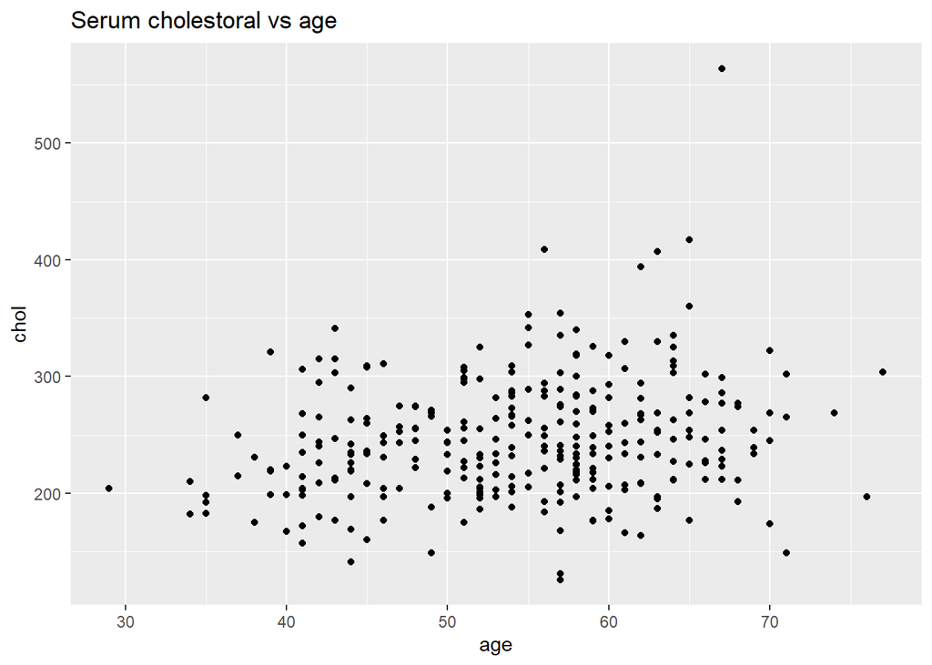

```r
library(ggplot2)
qplot(main = "Serum cholestoral vs age",
      x=age, y=chol, data=health_heart, geom="point")
```

b) Realizar un gráfico de barras para las variables “age” y “trestbps”.

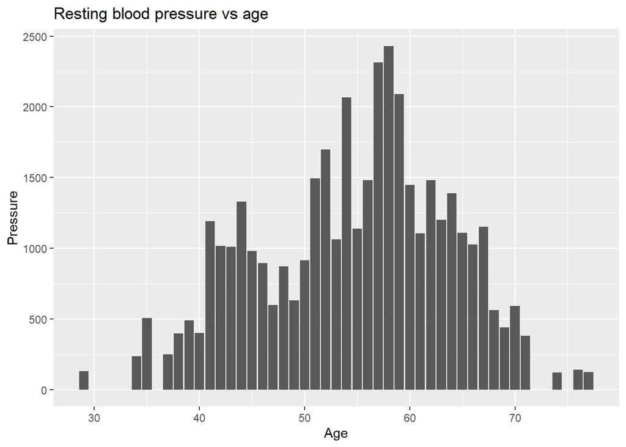

```r
ggplot(data = health_heart,  aes(x=age, y= trestbps)) +
  labs(title= "Resting blood pressure vs age", x="Age", y="Pressure") +
  geom_col()
```

6.2. Realizad un breve estudio de regresión y correlación lineal, resolviendo las siguientes cuestiones: a) Realizad un diagrama de cajas sobre las variables “age” y “thalach”. ¿Qué se puede extraer de este gráfico?

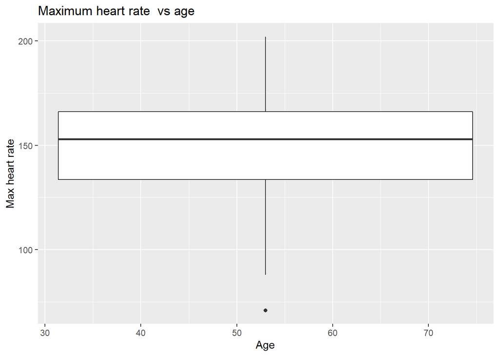

```r
ggplot(data = health_heart,  aes(x=age, y= thalach, group=1)) +
  labs(title= "Maximum heart rate  vs age", x="Age", y="Max heart rate") +
  geom_boxplot()
```

El grueso de nuestros valores “heart rate” se encuentran entre 125 y 175. Tiene una dispersión equilibrada. Vemos un valor extremo tambien en la parte baja de la grafica.

2. Realizad un modelo de regresión para las dos variables anteriores y un diagrama de puntos que ajuste al modelo anterior. ¿Qué conclusiones pueden obtenerse?

```r
modelo <- lm(health_heart$thalach~health_heart$age, data=health_heart)
summary(modelo)
```

```
##
## Call:
## lm(formula = health_heart$thalach ~ health_heart$age, data = health_heart)
##
## Residuals:
##     Min      1Q  Median      3Q     Max
## -65.949 -11.954   3.975  15.921  44.985
##
## Coefficients:
##                  Estimate Std. Error t value Pr(>|t|)
## (Intercept)      204.2892     7.3485  27.800  < 2e-16 ***
## health_heart$age  -1.0051     0.1333  -7.539 5.63e-13 ***
## ---
## Signif. codes:  0 '***' 0.001 '**' 0.01 '*' 0.05 '.' 0.1 ' ' 1
##
## Residual standard error: 21.04 on 301 degrees of freedom
## Multiple R-squared:  0.1588, Adjusted R-squared:  0.156
## F-statistic: 56.83 on 1 and 301 DF,  p-value: 5.628e-13
```

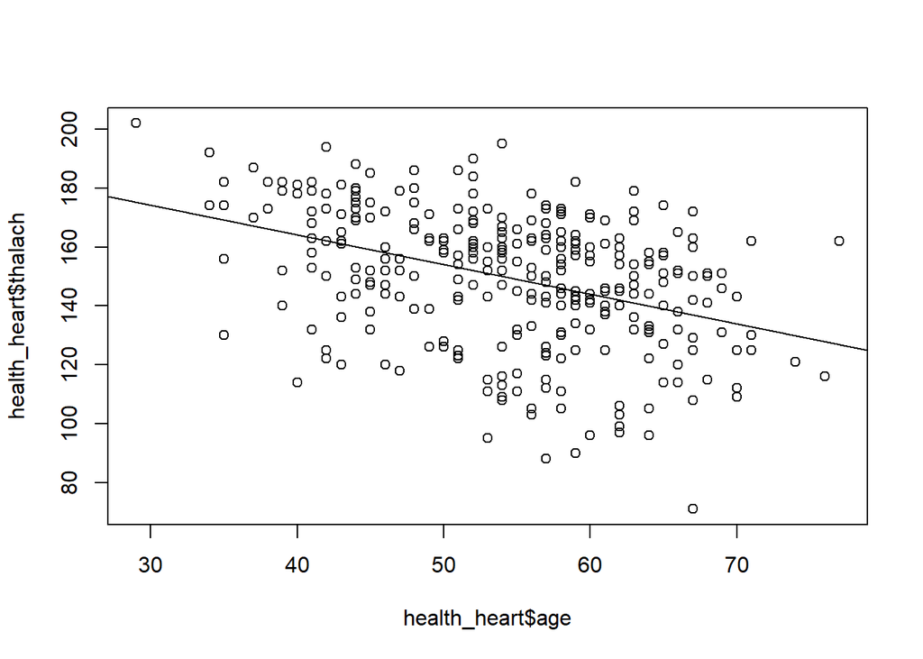

```r
plot(health_heart$age, health_heart$thalach)
abline(modelo)
```

```r
cor.test(health_heart$age, health_heart$thalach,
                               method="pearson")
```

```
##
##  Pearson's product-moment correlation
##
## data:  health_heart$age and health_heart$thalach
## t = -7.5386, df = 301, p-value = 5.628e-13
## alternative hypothesis: true correlation is not equal to 0
## 95 percent confidence interval:
##  -0.4892312 -0.2992831
## sample estimates:
##        cor
## -0.3985219
```

Podemos ver que si hay una tendencia, pero hay una correlación baja entre las variables

3. Realizad la matriz de correlación del conjunto de datos health_heart. ¿Qué se puede afirmar?

```r
age <- c(health_heart$age)
thalach <- c(health_heart$thalach)
df <- data.frame(age, thalach)
cor(df)
```

```
##                age    thalach
## age      1.0000000 -0.3985219
## thalach -0.3985219  1.0000000
```

Reafirmamos en la poca dependencia de una variable respecto a la otra.

4. Calculad los residuos del modelo ajustado anterior y realizad un gráfico de normalidad.

```r
summary(modelo)
```

```
##
## Call:
## lm(formula = health_heart$thalach ~ health_heart$age, data = health_heart)
##
## Residuals:
##     Min      1Q  Median      3Q     Max
## -65.949 -11.954   3.975  15.921  44.985
##
## Coefficients:
##                  Estimate Std. Error t value Pr(>|t|)
## (Intercept)      204.2892     7.3485  27.800  < 2e-16 ***
## health_heart$age  -1.0051     0.1333  -7.539 5.63e-13 ***
## ---
## Signif. codes:  0 '***' 0.001 '**' 0.01 '*' 0.05 '.' 0.1 ' ' 1
##
## Residual standard error: 21.04 on 301 degrees of freedom
## Multiple R-squared:  0.1588, Adjusted R-squared:  0.156
## F-statistic: 56.83 on 1 and 301 DF,  p-value: 5.628e-13
```

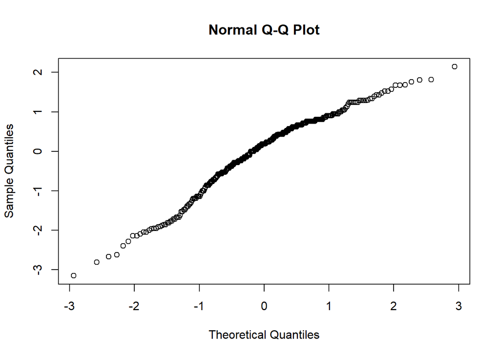

```r
residuos <- rstandard(modelo)
qqnorm(residuos)
```

EJERCICIO 7. A partir del conjunto de datos “women” del paquete MASS, guardad en un vector la altura (height) de las mujeres cuyo peso (weight) es superior a 131lb e inferior a 150lb.

```r
library(MASS) #cargamos el paquete
data("women")
table <- data.frame(women)

height_women <- c()#Creo el vector vacio
j <- 1  #Creo la instancia j que señala al valor 1 que me dara la posición
        #equivalente de la [i] en el vector

F_height <- function(){   #creo la función
  for(i in 1:length(women$height))  #hago el bucle
    if (women$weight[i] > 131)      #creo las condiciones
    if (women$weight[i] < 150) {
      height_women[j] <- women$height[i]  #Voy añadiendo los valores al vector
      j <- j + 1 #Asi voy añadiendo en la posición equivalente
    }
  return (height_women)
}
heigth <- F_height()
heigth
```

```
## [1] 64 65 66 67 68
```

Calculad la media del vector y las posiciones asociadas (del conjunto de datos “women”) a los valores incluidos en el nuevo vector creado.

```r
mean(heigth)
```

```
## [1] 66
```

```r
match(heigth, women$height) #para encontrar las posiciones asociadas
```

```
## [1]  7  8  9 10 11
```

EJERCICIO 8. A partir del conjunto de datos “BOD” de la libreria RSQLite, realizad un breve estudio utilizando la sintaxis de SQL con R. En concreto, se pide:

1. Una lectura de las 4 primeras líneas del conjunto de datos.

```r
library(RSQLite)
library(sqldf)#cargamos la libreria
db <- "RSQLite"::datasetsDb()  #accedemos a las bases de datos de uno de los
#ficheros de RSQLite
dbReadTable(db, "BOD")#accedemos a BOD y lo guardamos en db
```

| Time | demand |
| --- | --- |
| 1 | 8.3 |
| 2 | 10.3 |
| 3 | 19.0 |
| 4 | 16.0 |
| 5 | 15.6 |
| 7 | 19.8 |

```r
sqldf("SELECT * FROM BOD LIMIT 4")
```

| Time | demand |
| --- | --- |
| 1 | 8.3 |
| 2 | 10.3 |
| 3 | 19.0 |
| 4 | 16.0 |

2. La información de la tabla ordenada de forma descendente de acuerdo a la variable “Demand”.

```r
sqldf("SELECT * FROM BOD ORDER BY demand DESC")
```

| Time | demand |
| --- | --- |
| 7 | 19.8 |
| 3 | 19.0 |
| 4 | 16.0 |
| 5 | 15.6 |
| 2 | 10.3 |
| 1 | 8.3 |

3. Los datos de la tabla cuyos valores de la variable “Demand” se encuentran entre 12 y 25.

```r
sqldf("SELECT * FROM BOD where demand > 12 AND demand < 25")
```

| Time | demand |
| --- | --- |
| 3 | 19.0 |
| 4 | 16.0 |
| 5 | 15.6 |
| 7 | 19.8 |